# 01847291_Coursework1

We now define a function to plot the ROC curve from the actual outcomes and the predicted probabilities.

```python
def roc_curve(y_true, y_prob):
    """
    Arguments:
    y_true: ground truth labels with size (n, )
    y_prob: probabilities produced by logistic function with size (n, )

    Returns:
    auc: area under the curve (AUC).
    tpr_l: a list of true positive rate (TPR) values for each scanned threshold.
    fpr_l: a list of false positive rate (FPR) values for each scanned threshold.
    thresholds: the scanned thresholds sorted descendingly.
    """

    # List of distinct values in y_log, sorted descendingly.
    thresholds = reversed(sorted(set(y_prob)))
    tpr_l, fpr_l = [], []
    #changing to boolean for computation of rates (needed for bitwise and operator)
    mappedy_true = np.array(y_true==1.).astype("int")
    for threshold in thresholds:
        # Apply thresholding
        y_thresholded = (y_prob >= threshold)
        # true positives
        tp = np.sum(mappedy_true & y_thresholded)
        # true negatives
        tn = np.sum((~mappedy_true) & (~y_thresholded))
        # false positives
        fp = np.sum((~mappedy_true) & y_thresholded)
        # false negatives
        fn = np.sum(mappedy_true & (~y_thresholded))

        tpr = tp / (tp + fn)
        fpr = fp / (tn + fp)
        tpr_l.append(tpr)
        fpr_l.append(fpr)

    # Compute AUC using Trapezoidal rule
    auc = np.trapz(tpr_l, fpr_l)
    return auc, tpr_l, fpr_l, thresholds
```

And plot the ROC for the weighted and unweighted rfs on the training data.

```python
#Get random forest for optimal unweighted
rf = train_rf(3, Xtrain, ytrain, max_depth=3)
#Get random forest for optimal weighted
rf_weighted = train_rf(5, Xtrain, ytrain, sample_weights=weights, max_depth=5)
#Get predicted probabilities for unweighted on train set
y_prob = predict_proba_rf(rf, Xtrain)
#Run ROC with these probs
auc, tpr, fpr, th = roc_curve(ytrain, y_prob)
#Get predicted probabilities for weighted on train set
y_prob_weighted = predict_proba_rf(rf_weighted, Xtrain)
#Run ROC with these probs
auc_w, tpr_w, fpr_w, th_w = roc_curve(ytrain, y_prob_weighted)
```

```
AUC = 0.9505260023818976
```

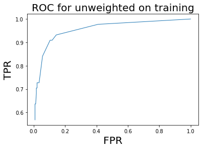

```python
#Plot ROC for unweighted
plt.title(f"ROC for unweighted on training", size=20)
ax = plt.subplot(111)
plt.plot(fpr, tpr, linewidth = 1)
plt.ylabel('TPR', size=20)
plt.xlabel('FPR', size=20)
print(f'AUC = {auc}')
```

```
AUC = 0.9808951965065502
```

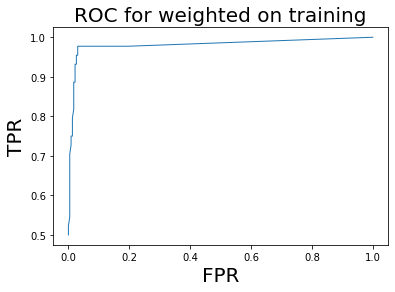

```python
#Plot ROC for weighted
plt.title(f"ROC for weighted on training", size=20)
ax = plt.subplot(111)
plt.plot(fpr_w, tpr_w, linewidth = 1)
plt.ylabel('TPR', size=20)
plt.xlabel('FPR', size=20)
print(f'AUC = {auc_w}')
```

```python
#Get predicted probabilities for unweighted on test set
y_prob = predict_proba_rf(rf, Xtest)
#Run ROC with these probs
auc, tpr, fpr, th = roc_curve(ytest, y_prob)
#Get predicted probabilities for weighted on test set
y_prob_weighted = predict_proba_rf(rf_weighted, Xtest)
#Run ROC with these probs
auc_w, tpr_w, fpr_w, th_w = roc_curve(ytest, y_prob_weighted)
```

```
AUC = 0.9229579207920792
```

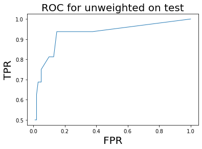

```python
#Plot ROC for unweighted
plt.title(f"ROC for unweighted on test", size=20)
ax = plt.subplot(111)
plt.plot(fpr, tpr, linewidth = 1)
plt.ylabel('TPR', size=20)
plt.xlabel('FPR', size=20)
print(f'AUC = {auc}')
```

```
AUC = 0.9306930693069307
```

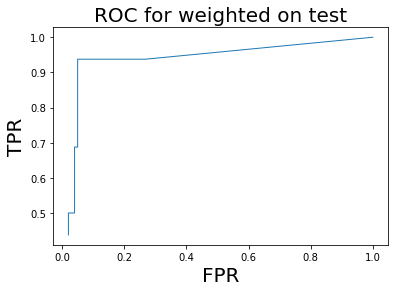

```python
#Plot ROC for weighted
plt.title(f"ROC for weighted on test", size=20)
ax = plt.subplot(111)
plt.plot(fpr_w, tpr_w, linewidth = 1)
plt.ylabel('TPR', size=20)
plt.xlabel('FPR', size=20)
print(f'AUC = {auc_w}')
```

We can now define the function for plotting the precison-recall curve.

```python
def pr_curve(y_true, y_prob):
    """
    Arguments:
    y_true: ground truth labels with size (n, )
    y_prob: probabilities produced by logistic function with size (n, )

    Returns:
    auc: area under the curve (AUC).
    tpr_l: a list of true positive rate (TPR) values for each scanned threshold.
    fpr_l: a list of false positive rate (FPR) values for each scanned threshold.
    thresholds: the scanned thresholds sorted descendingly.
    """

    # List of distinct values in y_log, sorted descendingly.
    thresholds = reversed(sorted(set(y_prob)))
    prec_l, rec_l = [1], [0]
    #changing to boolean for computation of rates (needed for bitwise and operator)
    mappedy_true = np.array(y_true==1.).astype("int")
    for threshold in thresholds:
        # Apply thresholding
        y_thresholded = (y_prob >= threshold)
        # true positives
        tp = np.sum(mappedy_true & y_thresholded)
        # true negatives
        tn = np.sum((~mappedy_true) & (~y_thresholded))
        # false positives
        fp = np.sum((~mappedy_true) & y_thresholded)
        # false negatives
        fn = np.sum(mappedy_true & (~y_thresholded))

        prec = tp / (tp + fp)
        rec = tp / (tp + fn)
        prec_l.append(prec)
        rec_l.append(rec)

    # Compute AUC using Trapezoidal rule
    auc = np.trapz(prec_l, rec_l)
    return auc, prec_l, rec_l, thresholds
```

```python
#Get probabilites for unweighted on training set
y_prob = predict_proba_rf(rf, Xtrain)
#Run pr-curve with these probs
auc, prec, rec, th = pr_curve(ytrain, y_prob)
#Get probabilites for weighted on training set
y_prob_weighted = predict_proba_rf(rf_weighted, Xtrain)
#Run pr-curve with these probs
auc_w, prec_w, rec_w, th_w = pr_curve(ytrain, y_prob_weighted)
```

```
AUC = 0.8630463830928676
```

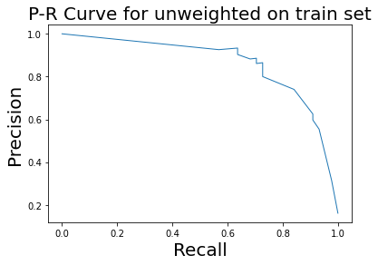

```python
#Plot PR for unweighted
plt.title(f"P-R Curve for unweighted on train set", size=20)
ax = plt.subplot(111)
plt.plot(rec, prec, linewidth = 1)
plt.ylabel('Precision', size=20)
plt.xlabel('Recall', size=20)
print(f'AUC = {auc}')
```

```
AUC = 0.9528104674833872
```

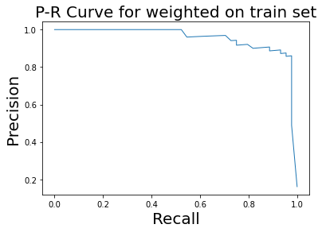

```python
#Plot PR for weighted
plt.title(f"P-R Curve for weighted on train set", size=20)
ax = plt.subplot(111)
plt.plot(rec_w, prec_w, linewidth = 1)
plt.ylabel('Precision', size=20)
plt.xlabel('Recall', size=20)
print(f'AUC = {auc_w}')
```

```python
#Get probabilites for unweighted on test set
y_prob = predict_proba_rf(rf, Xtest)
#Run pr-curve with these probs
auc, prec, rec, th = pr_curve(ytest, y_prob)
#Get probabilites for weighted on test set
y_prob_weighted = predict_proba_rf(rf_weighted, Xtest)
#Run pr-curve with these probs
auc_w, prec_w, rec_w, th_w = pr_curve(ytest, y_prob_weighted)
```

```
AUC = 0.7838784000537208
```

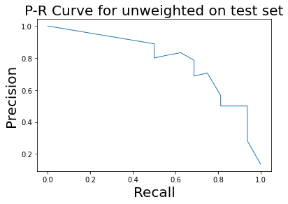

```python
#Plot PR for unweighted
plt.title(f"P-R Curve for unweighted on test set", size=20)
ax = plt.subplot(111)
plt.plot(rec, prec, linewidth = 1)
plt.ylabel('Precision', size=20)
plt.xlabel('Recall', size=20)
print(f'AUC = {auc}')
```

```
AUC = 0.7649782509157509
```

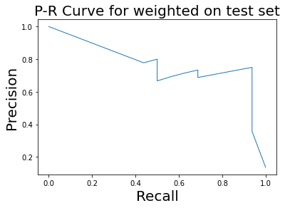

```python
#Plot PR for weighted
plt.title(f"P-R Curve for weighted on test set", size=20)
ax = plt.subplot(111)
plt.plot(rec_w, prec_w, linewidth = 1)
plt.ylabel('Precision', size=20)
plt.xlabel('Recall', size=20)
print(f'AUC = {auc_w}')
```

The ROC supports that the weighted bootstrap performs better than the standard bootstrap as it has a higher AUC on both the training and test set. Judging by the precision-recall curve we get that the weighted bootstrap performs better on the training set while the standard bootstrap performs better on the test set. This could indicate that the weighted version is overfit to the training data. It makes sense that the precision-recall curve is not necessarily better for the weighted bootstrap as while we expect recall to increase, precision may decrease.

### 2.2 Support Vector Machine (SVM)

For SVM we will re-import the data as we need to treat our data differently. First, we need to standardise because we will be calculating distance which is affected by scale. For a SVM we also need to convert the outcome variables into -1 and 1, we will choose -1 for no diabetes and 1 for diabetes.

```python
#Load in training and testing data using pandas
diabetes_train = pd.read_csv('diabetes_samples.csv')
diabetes_test = pd.read_csv('diabetes_test.csv')

#Clean the data
for x in ['chol_hdl_ratio', 'bmi', 'waist_hip_ratio']:
    diabetes_train[x] = pd.to_numeric(diabetes_train[x].str.replace(',', '.'))
    diabetes_test[x] = pd.to_numeric(diabetes_test[x].str.replace(',', '.'))

#Convert categorical labels to numbers
diag_map = {'Diabetes': 1.0, 'No diabetes': -1.0}
diabetes_train['diabetes'] = diabetes_train['diabetes'].map(diag_map)
diabetes_test['diabetes'] = diabetes_test['diabetes'].map(diag_map)
```

```python
#Convert data to np arrays
train = diabetes_train.to_numpy()
test = diabetes_test.to_numpy()

Xtrain = train[:,:-1]
ytrain = train[:,-1]
Xtest = test[:,:-1]
ytest = test[:,-1]

#Standardize train and test sets
stdXtrain, params = standardise(Xtrain)
stdXtest = np.empty(Xtest.shape)
for i in range(Xtest.shape[1]):
    mu, sig = params[i]
    stdXtest[:,i] = (Xtest[:,i] - mu)/sig

# insert 1 in every row for intercept b
stdXtrain_intercept = np.hstack((stdXtrain, np.ones((len(stdXtrain),1)) ))
stdXtest_intercept = np.hstack((stdXtest, np.ones((len(stdXtest),1)) ))
```

We define the loss function as $$ \mathcal L (\boldsymbol w) = \frac{1}{2} \| \boldsymbol w \|^2 + \lambda \sum_{i=1}^n \max \bigg( 0, 1-y_i (x^{(i)} \cdot \boldsymbol w + b) \bigg) \, . $$ where $\boldsymbol w$ is the vector of weights, $\lambda$ the regularisation parameter, and $b$ the intercept which is included in our `X` as an additional column of $1$'s. Let's implement this as a function:

```python
def compute_cost(w, X, y, regul_strength=1e5):
    """
    Arguments:
    w: vector of weights
    X: predictor set with additional column of 1s
    y: outcome set
    regul_strength: lambda

    Output:
    Computed cost
    """
    #Calculate distances
    distances = 1 - y * (X @ w)
    distances[distances < 0] = 0  # equivalent to max(0, distance)
    hinge = regul_strength * distances.sum()

    # Calculate cost
    return 0.5 * np.dot(w, w) + hinge -0.5*w[-1]**2
```

One way to optimize the cost is by using stochastic gradient descent (SGD) algorithm. In order to use SGD, we need to implement a function for the cost gradients with respect to $\boldsymbol w$.

```python
#Calculate gradient of cost
def calculate_cost_gradient(w, X_batch, y_batch, regul_strength=1e6):
    # if only one example is passed
    if type(y_batch) == np.float64:
        y_batch = np.asarray([y_batch])
        X_batch = np.asarray([X_batch])  # gives multidimensional array

    distance = 1 - (y_batch * (X_batch @ w))
    dw = np.zeros(len(w))

    we = w.copy() # So as not to overwrite w
    we[-1] = 0 # So as not to have b in its derivative when adding the weights in di

    for ind, d in enumerate(distance):
        if max(0, d)==0:
            di = 0 # derivative of first term
        else:
            di = - (regul_strength * y_batch[ind] * X_batch[ind])
        dw += di
    dw += we

    return dw
```

Both of the two previous functions are then used in `sgd` to update the weights iteratively with a given learning rate $\alpha$. We also implement a stop criterion that ends the learning as soon as the cost function has not changed more than a manually determined percentage.

We know that the learning happens through updating the weights according to $$ \boldsymbol w = \boldsymbol w - \alpha \frac{\partial \mathcal L}{\partial \boldsymbol w} $$

where $\frac{\partial \mathcal L}{\partial \boldsymbol w}$ is the gradient of the hinge loss we have computed in the previous cell.

```python
def sgd(X, y, max_iterations=2000, stop_criterion=0.01, learning_rate=1e-5, regul_strength=1e6, print_outcome=False):

  # initialise zero weights
  weights = np.zeros(X.shape[1])
  nth = 0
  # initialise starting cost as infinity
  prev_cost = np.inf

  # stochastic gradient descent
  indices = np.arange(len(y))

  for iteration in range(1, max_iterations):
    # shuffle to prevent repeating update cycles
    np.random.shuffle(indices)
    X, y = X[indices], y[indices]

    for xi, yi in zip(X, y):
      descent = calculate_cost_gradient(weights, xi, yi, regul_strength) ## <-- SOLUTION
      weights = weights - (learning_rate * descent)

    # convergence check on 2^n'th iteration
    if iteration==2**nth or iteration==max_iterations-1:
      # compute cost
      cost = compute_cost(weights, X, y, regul_strength)  ## <-- SOLUTION
      if print_outcome:
        print("Iteration is: {}, Cost is: {}".format(iteration, cost))
      # stop criterion
      if abs(prev_cost - cost) < stop_criterion * prev_cost:
        return weights

      prev_cost = cost
      nth += 1

  return weights
```

We will run a cross-validation to tune the hyperparameter $\lambda$. In order to evaluate the mean accuracy in both train and test set, we write a small function called `score_svm`.

```python
def score_svm(w, X, y):
  y_preds = np.sign(X @ w)
  return np.mean(y_preds == y)
```

We write a function to get the indices for each fold split.

```python
def cross_val_split(N, num_folds):
    fold_size = N // num_folds
    #set seed for reproducibility
    np.random.seed(5)
    index_perm = np.random.permutation(np.arange(N))
    folds = []
    for k in range(num_folds):
        folds.append(index_perm[k*fold_size:(k+1)*fold_size])
    return folds
```

Now we write our functions to perform a cross validation and choose the optimal hyperparameter.

```python
def cross_val_evaluate(data, num_folds, l):
  folds = cross_val_split(data.shape[0], num_folds)

  train_scores = []
  val_scores = []

  for i in range(len(folds)):

    val_indices = folds[i]
    # define the training set
    train_indices = list(set(range(data.shape[0])) - set(val_indices))

    X_train = data[train_indices,  :-1]  ## <-- SOLUTION
    y_train = data[train_indices, -1]

    # define the validation set
    X_val = data[val_indices,  :-1]  ## <-- SOLUTION
    y_val = data[val_indices, -1]  ## <-- SOLUTION

    # insert 1 in every row for intercept b
    X_train = np.hstack((X_train, np.ones((len(X_train),1)) ))
    X_val = np.hstack((X_val, np.ones((len(X_val),1)) ))

    # train the model
    w = sgd(X_train, y_train, max_iterations=2000, stop_criterion=0.01, learning_rate=1e-5, regul_strength=l)

    # evaluate
    train_score = score_svm(w, X_train, y_train)
    val_score = score_svm(w, X_val, y_val)

    train_scores.append(train_score)
    val_scores.append(val_score)

  return np.mean(val_scores)
```

```python
def choose_best_svm(traindata, num_folds, l_range,show=False,printing=False):
    #Initialise lambdas
    l_scores = np.zeros((len(l_range),))

    #Iterate over lambda range
    for i, l in enumerate(l_range):
        l_scores[i] = cross_val_evaluate(traindata, num_folds, l)

        #Print each accuracy score
        if printing:
            print(f'lambda={l}, accuracy={l_scores[i]:.5f}')
    out = (l_range[np.argmax(l_scores)],max(l_scores))
    #plotting grid search
    if show:
        plt.figure(figsize=(15, 8))
        plt.scatter(l_range,l_scores)
        plt.scatter(out[0],out[1],color='red',marker="x",label="Best accuracy")
        plt.xlabel("lambda")
        plt.ylabel("Accuracy scores from cross validation")
        plt.title("Scan for optimum lambda value over cross validation")
        plt.legend()
        plt.show()
    return out
```

Now we can run a 4-fold cross validation to optimise the hardness hyperparameter $\lambda$.

```
lambda=1, accuracy=0.87132
lambda=2, accuracy=0.87132
lambda=3, accuracy=0.87132
lambda=4, accuracy=0.89338
lambda=5, accuracy=0.89338
lambda=6, accuracy=0.89706
lambda=7, accuracy=0.89706
lambda=8, accuracy=0.90074
lambda=9, accuracy=0.90441
lambda=10, accuracy=0.90809
lambda=11, accuracy=0.90809
lambda=12, accuracy=0.90809
lambda=13, accuracy=0.91176
lambda=14, accuracy=0.90809
```

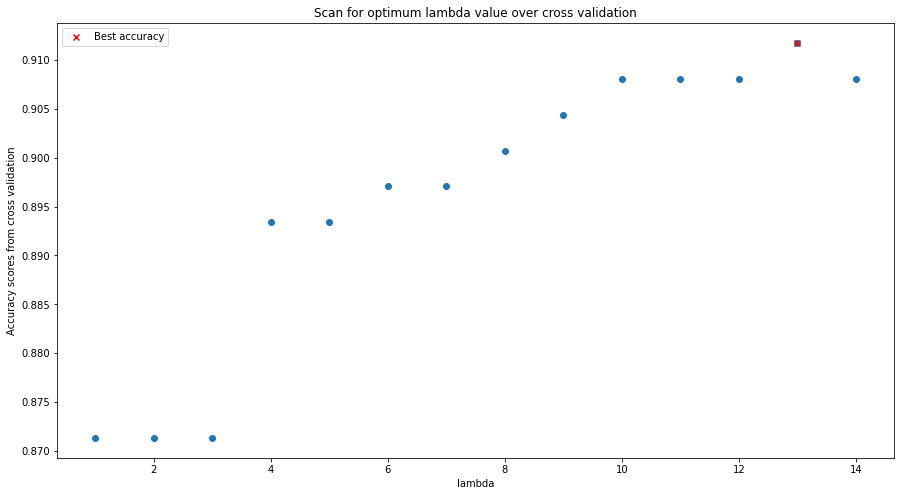

```
(13, 0.911764705882353)
```

```python
choose_best_svm(np.concatenate((stdXtrain_intercept,ytrain[:,np.newaxis]),axis=1), 4, np.arange(1,15),show=True,printing=True)
```

We see that as we increase $\lambda$ (more hardness), the accuracy seems to increase. So we try a larger range of values for $\lambda$.

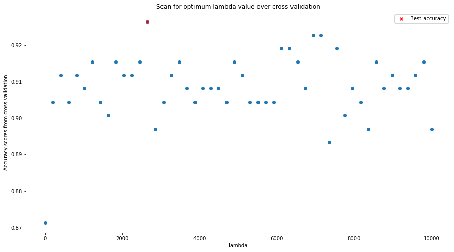

```
(2653.7959183673465, 0.9264705882352942)
```

```python
choose_best_svm(np.concatenate((stdXtrain_intercept,ytrain[:,np.newaxis]),axis=1), 4, np.linspace(1,10000,50),show=True,printing=False)
```

Increasing $\lambda$ increases hardness so the margin is built such that points cannot lie in it. Evidently, from our larger search it is not necessarily that the average accuracy increases as $\lambda$ is increased. This is because as we increase hardness we can get more overfitting to the training sets and lower accuracy on the validation sets.

The difference between a hard margin and a soft margin in SVMs lies in the separability of the data. If we have linearly separable data, we go for a hard margin. However, if this is not the case, it won’t be feasible to do that. In the presence of the data points that make it impossible to find a linear classifier, we would have to be more lenient and let some of the data points be misclassified. In this case, a soft margin SVM is appropriate. The data may also be linearly separable, but with a margin so small that the model becomes prone to overfitting or being too sensitive to outliers. Also, in this case, we can opt for a larger margin by using soft margin SVM in order to help the model generalize better.

As we are using a stochastic gradient descent method instead of actually having a solution to the loss funciton we also have to account for the fact that for large $\lambda$ the gradient doesn't necessarily converge so we will proceed with the initial optimal $\lambda$ of 13.

Now, we define a function to calculate the cosine of the angle between two hyperplanes. This will be the same between the cosine of the angle of their norm vectors. We can use a rearrangement of the dot product rule to find this.

```python
#Find cosine of angle between two norm vectors
def cos_angle(w1, w2):
    return np.dot(w1,w2)/(np.linalg.norm(w1)*np.linalg.norm(w2))
```

And a function to get the cosine of angles between the hyperplanes for each $\lambda$ in a given range.

```python
#Get cos of the angle for every combination of hyperplanes
def cos_heatmap(traindata, l_range, show=False,printing=False):
    #Initialise lists of cos values and norm vectors
    cos_values = []
    ws = []
    #Split into predictors and outcomes
    X_train = traindata[:,:-1]
    y_train = traindata[:, -1]
    #Loop over all lambda in the range
    for count, l in enumerate(l_range):
        #Get norm vector for l
        w = sgd(X_train, y_train, max_iterations=2000, stop_criterion=0.001, learning_rate=1e-5, regul_strength=l, print_outcome=False)
        ws.append(w)
    #Loop through each combination of lambdas
    for count1, l1 in enumerate(l_range):
        cos = []
        for count2, l2 in enumerate(l_range):
            #Get cos of angle
            cos.append(cos_angle(ws[count1], ws[count2]))
        cos_values.append(cos)

    return cos_values
```

We then plot a square heatmap of the cosine of the angle between each pair of hyperplanes in our initial range of $\lambda$ values from the grid search in 2.2.1

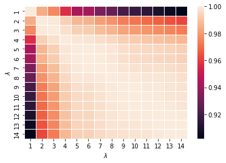

```python
#Run cos_heatmap to get each cos value in given range
cos_values = cos_heatmap(np.concatenate((stdXtrain_intercept,ytrain[:,np.newaxis]),axis=1), np.arange(1,15), show=False,printing=False)
#Use seaborn to plot heatmap of the values
ax = sns.heatmap(cos_values, xticklabels = np.arange(1,15), yticklabels = np.arange(1,15), linewidth=0.5)
plt.xlabel('$\lambda$')
plt.ylabel('$\lambda$')
plt.show()
```

We see that most of the cosine values are near 1, with the lowest cosine values coming from the angle between hyperplanes for $\lambda$s with large differences. A cosine value of 1 indicates an angle of zero, so the hyperplanes are parallel. This makes sense as we would expect the hyperplanes to be very similar for similar values of $\lambda$.

Now we fix $\lambda$ to its optimal value of 13 and re-train the linear SVM on the full training set.

```python
w = sgd(stdXtrain_intercept, ytrain, max_iterations=10000, stop_criterion=0.001, learning_rate=1e-5, regul_strength=13, print_outcome=True)
```

```
Iteration is: 1, Cost is: 3434.215098350598
Iteration is: 2, Cost is: 3319.587614991256
Iteration is: 4, Cost is: 3090.807816018451
Iteration is: 8, Cost is: 2635.084363604993
Iteration is: 16, Cost is: 1893.1940852853018
Iteration is: 32, Cost is: 1136.6485287450255
Iteration is: 64, Cost is: 766.1085762714363
Iteration is: 128, Cost is: 724.0758283368782
Iteration is: 256, Cost is: 711.6415499881342
Iteration is: 512, Cost is: 704.8325670069564
Iteration is: 1024, Cost is: 699.4982892502645
Iteration is: 2048, Cost is: 698.0310619497521
Iteration is: 4096, Cost is: 697.9186192162118
```

In order to evaluate its performance we will need to define a function that lets us make predictions from the SVM.

```python
#Predict from dataset X using vector w
def predict_svm(w, X):
    xw_b = X @ w
    y_pred = np.zeros_like(xw_b)
    for count, i in enumerate(xw_b):
        if i >= 0:
            y_pred[count] = 1
        else:
            y_pred[count] = -1
    return y_pred
```

We need to redefine our confusion matrix function to use our new prediction function for SVMs and given that our outcome variables are now -1 and 1.

```python
def confmatrix_svm(w, X, y):
    #Get predictions
    y_pred = predict_svm(w, X)
    ytest = np.asarray(y)
    #Initialise matrix
    mat = np.zeros((2,2))
    #Get values for each cell in matrix
    for truth, pred in zip(ytest,y_pred):
        if truth == 1 and pred == 1:
            mat[0,0] += 1
        if truth == -1 and pred == 1:
            mat[0,1] += 1
        if truth == 1 and pred == -1:
            mat[1,0] += 1
        if truth == -1 and pred == -1:
            mat[1,1] += 1
    return mat
```

Now we can get our confusion matrices and the appropriate performance measures on the training and test data.

```python
#Visualise Confusion matrix for training set
ctrain = confmatrix_svm(w, stdXtrain_intercept, ytrain)
percentages = ctrain/sum(sum(ctrain))*100
print("Confusion matrix of training data")
print(tabulate(percentages, tablefmt='fancy_grid'))
```

```
Confusion matrix of training data
╒═════════╤═════════╕
│ 8.79121 │  1.4652 │
├─────────┼─────────┤
│ 7.32601 │ 82.4176 │
╘═════════╧═════════╛
```

```python
#Visualise Confusion matrix for test set
ctest = confmatrix_svm(w, stdXtest_intercept, ytest)
percentages = ctest/sum(sum(ctest))*100
print("Confusion matrix of test data")
print(tabulate(percentages, tablefmt='fancy_grid'))
```

```
Confusion matrix of test data
╒═════════╤═════════╕
│ 6.83761 │  1.7094 │
├─────────┼─────────┤
│ 6.83761 │ 84.6154 │
╘═════════╧═════════╛
```

```python
print("Accuracy from training data:", accuracy(ctrain))
print("Accuracy from test data:", accuracy(ctest))
```

```
Accuracy from training data: 0.9120879120879121
Accuracy from test data: 0.9145299145299145
```

```python
print("Precision from training data:", precision(ctrain))
print("Precision from test data:", precision(ctest))
```

```
Precision from training data: 0.8571428571428571
Precision from test data: 0.8
```

```python
print("F-score from training data:", fscore(ctrain))
print("F-score from test data:", fscore(ctest))
```

```
F-score from training data: 0.6666666666666665
F-score from test data: 0.6153846153846154
```

For our optimal value of $\lambda$, we see that we get a high accuracy on both the training and test set. The precision is fairly high but we have a very poor f-score on both the training data set. This is an issue again due to the nature of our data we want to minimise the number of false negatives.

We will now implement a soft-margin kernelised SVM classifier by minimising the loss function:

$$L(\mathbf{u},b) = \frac{1}{2}\mathbf{u}^{\rm{T}}\mathbf{K} \mathbf{u} + \lambda \sum_{i=1}^N \max \Big\{0, 1-y^{(i)}(\mathbf{K}^{(i)}\mathbf{u} + b)\Big\}$$

where the kernel is the sigmoid kernel: $$[\mathbf{K}]_ij \equiv k(\mathbf{x}^{(i)},\mathbf{x}^{(j)}) = \text{tanh}(\sigma(\mathbf{x}^{(i)} \cdot \mathbf{x}^{(j)}) + 1)$$

First we write a function to calculate the kernel given the data.

```python
def kernel_matrix(X1,X2,sigma):

    n1,m1 = X1.shape
    n2,m2 = X2.shape
    kernel = np.zeros((n1,n2))

    # Here we define a Sigmoid Kernel
    for i in range(n1):
        for j in range(n2):
            kernel[i,j] = np.tanh(sigma* np.dot(X2[j], X1[i]) + 1)

    return kernel
```

Having defined the kernel, we use this to compute the cost below.

```python
def compute_cost_kernel(u, K, y, regul_strength=10,intercept=0):

    # Here I define the hinge cost with the kernel trick. NB: the intercept should be kept separate #

    distances = 1 - (y)*(K@u + intercept)
    distances[distances < 0] = 0  # equivalent to max(0, distance)
    hinge = regul_strength * distances.sum()

    # calculate cost
    return 0.5 * np.dot(u,K@u) + hinge
```

Following the steps above, we want to optimize the cost is by using SGD. First, we thus create a function that computes the gradients.

```python
def calculate_cost_gradient_kernel(u, K_batch, y_batch, regul_strength=10,intercept=0):

    # if only one example is passed
    if type(y_batch) == np.float64 or type(y_batch) == np.int32:
        y_batch = np.asarray([y_batch])
        K_batch = np.asarray([K_batch])  # gives multidimensional array

    distance = 1 - (y_batch * (K_batch @ u + intercept)) ## <-- SOLUTION
    dw = np.zeros(len(u))

    # define the gradient with the hinge loss #
    for ind, d in enumerate(distance):
        if max(0, d)==0:
            di = 0 ## <-- SOLUTION
        else:
            di = - (regul_strength * y_batch[ind] * K_batch[ind]) ## <-- SOLUTION
        dw += di
    dw += K_batch @ u

    return dw
```

We can now use the functions above in SGD. Our update for the intercept is chosen as the average of the distance to the closest negative and positive case.

```python
def sgd_kernel(K, y, batch_size=32, max_iterations=4000, stop_criterion=0.001, learning_rate=1e-4, regul_strength=10, print_outcome=False):

    # initialise zero u and intercept
    u = np.zeros(K.shape[1])
    intercept=0

    nth = 0
    # initialise starting cost as infinity
    prev_cost = np.inf

    # stochastic gradient descent
    indices = np.arange(len(y))
    for iteration in range(1, max_iterations):
        # shuffle to prevent repeating update cycles
        np.random.shuffle(indices)
        batch_idx = indices[:batch_size]
        K_b, y_b = K[batch_idx], y[batch_idx]
        for ki, yi in zip(K_b, y_b):
            ascent = calculate_cost_gradient_kernel(u, ki, yi, regul_strength, intercept) # <-- SOLUTION
            u = u - (learning_rate * ascent)
            #calculate closest of each case
            min_dist = np.min((K_b @ u)[y_b == 1])
            max_dist = np.max((K_b @ u)[y_b == -1])
            #calculate new intercept
            intercept = (min_dist + max_dist)/2

        # convergence check on 2^n'th iteration
        if iteration==2**nth or iteration==max_iterations-1:
            # compute cost
            cost = compute_cost_kernel(u, K, y, regul_strength, intercept)
            if print_outcome:
                print("Iteration is: {}, Cost is: {}".format(iteration, cost))
            # stop criterion
            if abs(prev_cost - cost) < stop_criterion * prev_cost:
                return u, intercept

            prev_cost = cost
            nth += 1

    return u, intercept
```

We now fix $\lambda$ = 10 and train the soft margin kernelised SVM classifier on the training set for each value of $\sigma$ = 0.01, 0.1, 1, 2. We report the acccuracy socres and the inferred intercept for each $\sigma$.

```python
for sigma in [0.01,0.1,1,2]:

    print('For sigma = ' + str(sigma))
    K_train = kernel_matrix(stdXtrain,stdXtrain, sigma)

    u,b = sgd_kernel(K_train, ytrain, batch_size=128, max_iterations=2000, stop_criterion=0.001, learning_rate=1e-5, regul_strength=10, print_outcome=False)

    def score(u, X, y, sigma, intercept):
        ## now I define the kernel containing test and train data ##
        K_test = kernel_matrix(X,stdXtrain, sigma)

        ## The
        y_preds = np.sign(K_test@u + intercept) ## <-- SOLUTION

        return np.mean(y_preds == y)

    print("Accuracy on training set: {}".format(score(u, stdXtrain, ytrain, sigma, b)))
    print("Accuracy on test set: {}".format(score(u, stdXtest, ytest, sigma, b)))
    print("Inferred intercept: {}".format(b))
```

```
For sigma = 0.01
Accuracy on training set: 0.8388278388278388
Accuracy on test set: 0.8632478632478633
Inferred intercept: -0.5032812207580573
For sigma = 0.1
Accuracy on training set: 0.9377289377289377
Accuracy on test set: 0.905982905982906
Inferred intercept: 0.4546435462638361
For sigma = 1
Accuracy on training set: 0.4065934065934066
Accuracy on test set: 0.3504273504273504
Inferred intercept: 13.120433609422292
For sigma = 2
Accuracy on training set: 0.4945054945054945
Accuracy on test set: 0.41025641025641024
Inferred intercept: 7.999601028341714
```

We now want to find our confusion matrices and the associated performance measures for each $\sigma$. First we will need to redefine the confusion matrix to take predictions from our new kernelised SVM.

```python
def confmatrix_kernel(y_pred,y):
    ytest = np.asarray(y)
    #Initialise matrix
    mat = np.zeros((2,2))
    #Get values for each cell in matrix
    for truth, pred in zip(ytest,y_pred):
        if truth == 1 and pred == 1:
            mat[0,0] += 1
        if truth == -1 and pred == 1:
            mat[0,1] += 1
        if truth == 1 and pred == -1:
            mat[1,0] += 1
        if truth == -1 and pred == -1:
            mat[1,1] += 1
    return mat
```

Now for each $\sigma$ we visualise our confusion matrix on the test set and calculate the accuracy, precision and F-score.

```python
for sigma in [0.01,0.1,1,2]:

    K_train = kernel_matrix(stdXtrain,stdXtrain, sigma)

    u,b = sgd_kernel(K_train, ytrain, batch_size=128, max_iterations=2000, stop_criterion=0.001, learning_rate=1e-5, regul_strength=10, print_outcome=False)

    K_test = kernel_matrix(stdXtest,stdXtrain, sigma)
    y_preds = np.sign(K_test@u + b)

    ctest = confmatrix_kernel(y_preds, ytest)
    percentages = ctest/sum(sum(ctest))*100
    print('For sigma = ' + str(sigma))
    print("Confusion matrix for test data")
    print(tabulate(percentages, tablefmt='fancy_grid'))

    print("Accuracy on test set: {}".format(accuracy(ctest)))
    print("Precision on test set: {}".format(precision(ctest)))
    print("F-score on test set: {}".format(fscore(ctest)))
    print( )
```

```
For sigma = 0.01
Confusion matrix for test data
╒═════════╤═════════╕
│  0      │  0      │
├─────────┼─────────┤
│ 13.6752 │ 86.3248 │
╘═════════╧═════════╛
Accuracy on test set: 0.8632478632478633
Precision on test set: 0.0
F-score on test set: 0.0
```

```
For sigma = 0.1
Confusion matrix for test data
╒═════════╤═════════╕
│ 5.98291 │  0      │
├─────────┼─────────┤
│ 7.69231 │ 86.3248 │
╘═════════╧═════════╛
Accuracy on test set: 0.9230769230769231
Precision on test set: 1.0
F-score on test set: 0.6086956521739131

For sigma = 1
Confusion matrix for test data
╒═════════╤═════════╕
│ 11.9658 │ 48.7179 │
├─────────┼─────────┤
│  1.7094 │ 37.6068 │
╘═════════╧═════════╛
Accuracy on test set: 0.49572649572649574
Precision on test set: 0.19718309859154928
F-score on test set: 0.3218390804597701

For sigma = 2
Confusion matrix for test data
╒═════════╤═════════╕
│ 11.9658 │ 54.7009 │
├─────────┼─────────┤
│  1.7094 │ 31.6239 │
╘═════════╧═════════╛
Accuracy on test set: 0.4358974358974359
Precision on test set: 0.1794871794871795
F-score on test set: 0.2978723404255319
```

We observe that our best case is when $\sigma = 0.1$ and we get an accuracy of 0.923 on the test set which is higher than the result for the linear SVM. We also observe that the precision is 1 as the model is not predicting any false positives. While this is impressive, due to the nature of the data being predicting diagnoses we likely are more concerned with minimising the number of false negatives. We see that we actual have a lower f-score in this kernelised SVM than for the original linear SVM. The higher accuracy for the kernelised model could mean that by lifting our data to a higher dimensional space, we were able to use a seperating hyperplane with low penalties.

However, we observe that our accuracy, precision and f-score for the rest of the $\sigma$ values are all worse than the results that we got from the linear SVM in 2.2.3 on the test set. This could indicate that our data is simple enough that a linear classifier is sufficient as the data is linearly separable and therefeore the kernel is not necessary. It's also possible that we are overfitting with the kernelised version and therfore performing worse on the test set.

As the kernelised model performed better in some measures for one value of $\sigma$ but worse for others we could perform further cross validation potentially with a finer interval of values near $\sigma$ = 0.1 to attain an optimal model. We could also perform cross validation on the other hyperparameters for the soft-margin kernelised SVM classifier. Our choice of $\lambda$ = 10 is not necessarily the optimal value whereas we did cross validate our $\lambda$ for the linear SVM. We also chose the value of c in the sigmoid kernel as 1 without cross validation to tune the hyperparameter.

We could also optimise the `batch_size`, `max_iterations`, `stop_criterion` and `learning_rate` in our stochastic gradient descent as it's possible the gradient is not convergeing and using optimal values will allow us to get the optimal values of u and b.

Across 2.1 and 2.2 the model with the highest accuracy on the test set was the kernelised SVM which also had the highest precision. However, the weighted bootstrap random forest classifier gave a higher f-score which as discussed is an important measure when predicting disease cases. Exploring the discussed potential improvements to the kernelised SVM it is possible that we attain a model that outperforms the weighted random forest in all measures and is a better fit for the data. Our dataset is relatively small so it is hard to train a good fit robust model.